# 7. Seasonal ARIMA

# (7-3) SRASONAL DIFFERENCES

[Nao Mimoto](https://nmimoto.github.io/) - [Dept. of Statistics](http://www.uakron.edu/stat/) : [The University of Akron](http://www.uakron.edu)

[TS Class Web Page](https://nmimoto.github.io/477/) – [R resource page](https://nmimoto.github.io/R/)

# 1. Effect of $\bigtriangledown_s$ on Trend

## a) Linear Trend

- Suppose $s=12$, and your observation $Y_t$ has linear trend, as well as the seasonality with period $s=12$.
  $$Y_t = a+b t + S_t + X_t.$$
  Then

  $$\begin{align*}
  \bigtriangledown_s Y_{t} &= \hspace{3mm} Y_{t+12}-Y_{t}\\\\
  &= \hspace{3mm} a+b (t+12) + S_{t+12} + X_{t+12} \\\\
  & \hspace{10mm} - \hspace{3mm} a+b (t) \hspace{5mm} + S_t \hspace{5mm} + X_t \\\\
  &= \hspace{3mm} b (12) + X_{t+12} - X_{t}\\
  \end{align*}$$

  This is statonary series with constant $b(12)$. (called **drift** by **auto.arima()**)

#### Quadratic Trend

- If your observation $Y_t$ has quadratic trend, as well as the seasonality.
  $$Y_t = a+b t + c t^2 + S_t + X_t.$$
  Then,
  $$\begin{align*}
  \bigtriangledown_s Y_{t} &= \hspace{3mm} Y_{t+12}-Y_{t} \\\\
  &= \hspace{3mm} a+b (t+12) + c(t+12)^2 + S_{t+12} + X_{t+12} \\\\
  &\hspace{10mm} - \hspace{3mm} a+b (t) + c(t^2) + S_t + X_t \\\\
  &= \hspace{3mm} b (12) + c(24 t) + c(12^2) + X_{t+12} - X_{t}\\
  \end{align*}$$
- This is statonary series with linear trend $b(12) + c(12^2) + c(24) t$.
- If you take $\bigtriangledown$ again, who will be left?

```r
  library(forecast)
  source('https://nmimoto.github.io/R/TS-00.txt')
```

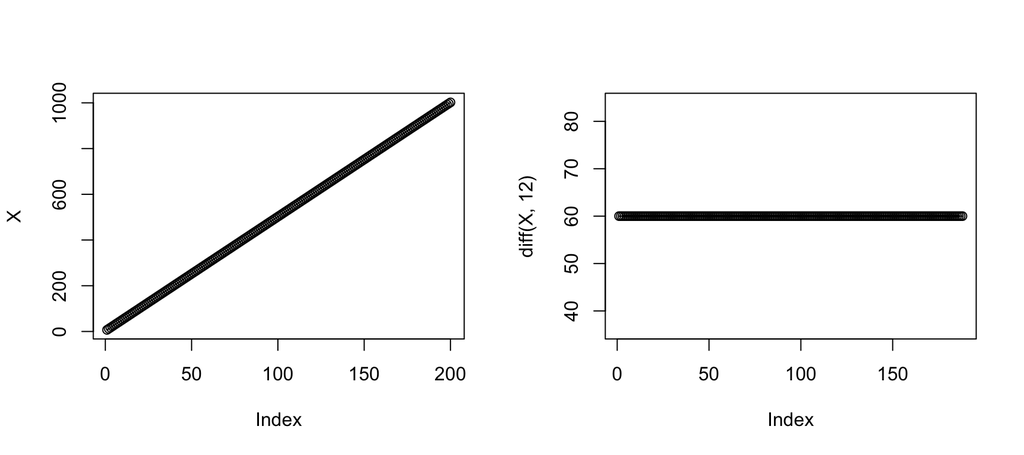

```r
  #--- Linear trend only
  X <- 2+5*(1:200)

  layout(matrix(1:2, 1,2))
  plot(X, type="o")
  plot(diff(X, 12), type="o")
```

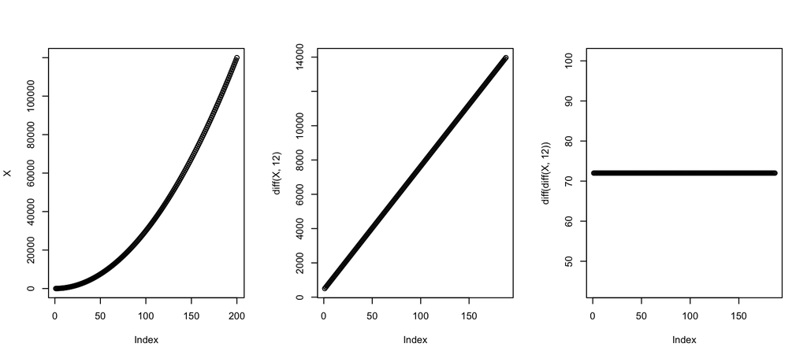

```r
  #--- Quadratic trend only
  X <- 2+3*(1:200)^2
  layout(matrix(1:3,1,3))
  plot(X, type="o")
  plot(diff(X, 12), type="o")
  plot(diff(diff(X, 12)), type="o")
```

## b) Linear Trend plus WN

- Suppose $s=12$, and your observation $Y_t$ has linear trend,
  $$Y_t = a+b t + S_t + e_t \hspace{10mm} \mbox{ where } e_t \sim N(0,1)$$
- Taking $\bigtriangledown_{12}$ yields,
  $$\begin{align*}
  Y_{t+12}-Y_{t} &= \hspace{3mm} a+b (t+12) + S_{t+12} + e_{t+12} \\\\
  &- ( a+b (t) \hspace{15mm} + S_t \hspace{5mm} + e_t ) \\\\
  &= \hspace{3mm} \hspace{10mm} b(12) + e_{t+12} - e_{t}
  \end{align*}$$
- What kind of process is this?
  $$K_t \hspace{3mm} = \hspace{3mm} e_{t} - e_{t-12}$$
- Linar regression with Seasonal average will be a better approach.

## __Ex. Linear Trend plus WN

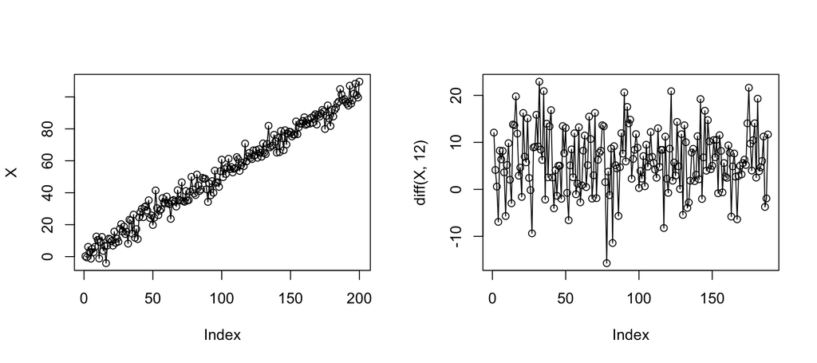

```r
  library(forecast)
  source('https://nmimoto.github.io/R/TS-00.txt')

  #--- Linear trend + WN
  set.seed(3462)
  X <- 2+.5*(1:200) + rnorm(200,0,5)
  layout(matrix(1:2,1,2))
  plot(X, type="o")
  plot(diff(X, 12), type="o")
```

```r
  auto.arima(X, D=1, stepwise=FALSE, approximation=FALSE) #D=1 is seasonal difference
```

```
## Series: X
## ARIMA(4,1,0) with drift
##
## Coefficients:
##           ar1      ar2      ar3      ar4   drift
##       -0.8011  -0.6471  -0.4556  -0.2376  0.5251
## s.e.   0.0690   0.0832   0.0833   0.0690  0.1130
##
## sigma^2 estimated as 25.36:  log likelihood=-602.02
## AIC=1216.04   AICc=1216.48   BIC=1235.8
```

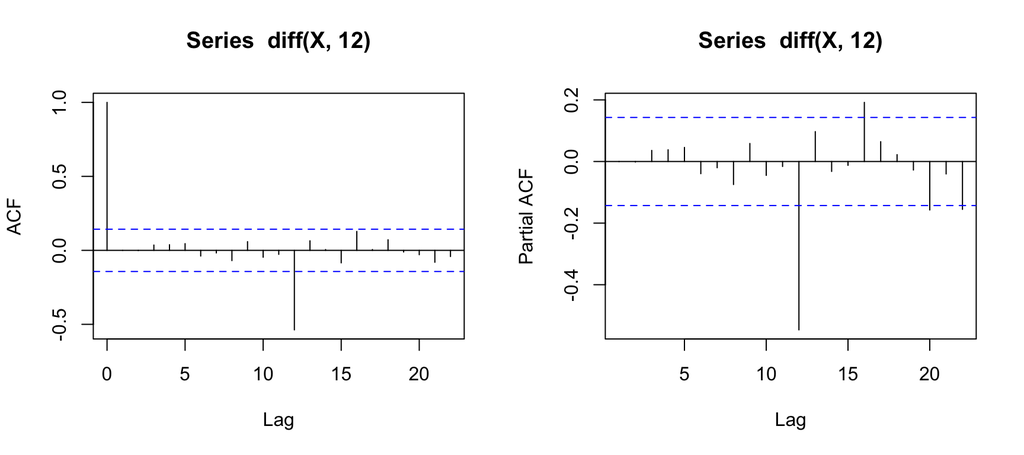

```r
    #- they won't pick up the seasonal term

  acf(diff(X,  12))   #- but seasonal dependence is still there
  pacf(diff(X, 12))
```

```r
  Fit1 <- Arima(X, order=c(0,0,0), seasonal=c(0,1,1))    #- try forceing sMA(1)
  Fit1                                                   #- doesn't work
```

```
## Series: X
## ARIMA(0,0,0) with non-zero mean
##
## Coefficients:
##          mean
##       52.2477
## s.e.   2.1032
##
## sigma^2 estimated as 889.2:  log likelihood=-962.31
## AIC=1928.63   AICc=1928.69   BIC=1935.23
```

#### Set frequency!

```r
  X2 <- ts(X, start=c(1,1), freq=12)           # set freq=12
  Fit2 <- auto.arima(X2, D=1, stepwise=FALSE)  # Now they do pick up the seasonal term
  Fit2
```

```
## Series: X2
## ARIMA(0,0,0)(2,1,0)[12] with drift
##
## Coefficients:
##          sar1     sar2   drift
##       -0.6780  -0.2089  0.5142
## s.e.   0.0719   0.0747  0.0181
##
## sigma^2 estimated as 29.7:  log likelihood=-586.82
## AIC=1181.63   AICc=1181.85   BIC=1194.58
```

```r
  Randomness.tests(Fit2$resid)
```

[output not shown]

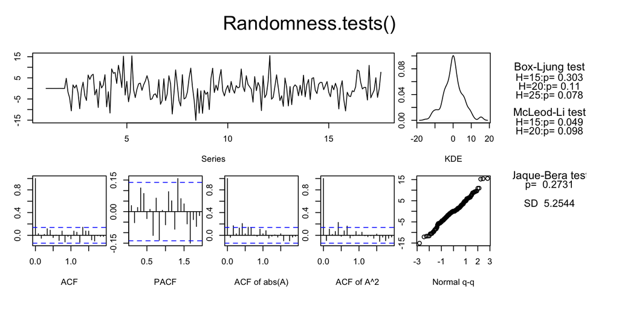

```
##   B-L test H0: the series is uncorrelated
##   M-L test H0: the square of the series is uncorrelated
##   J-B test H0: the series came from Normal distribution
##   SD         : Standard Deviation of the series
```

```
##       BL15 BL20  BL25  ML15  ML20    JB    SD
## [1,] 0.303 0.11 0.078 0.049 0.098 0.273 5.254
```

### Check for sign of (seasonal) over-differencing

```r
  Fit3 <- Arima(X2, order=c(0,0,0), seasonal=c(0,1,1))
  Fit3
```

```
## Series: X2
## ARIMA(0,0,0)(0,1,1)[12]
##
## Coefficients:
##         sma1
##       0.0767
## s.e.  0.0542
##
## sigma^2 estimated as 82.46:  log likelihood=-681.05
## AIC=1366.1   AICc=1366.17   BIC=1372.57
```

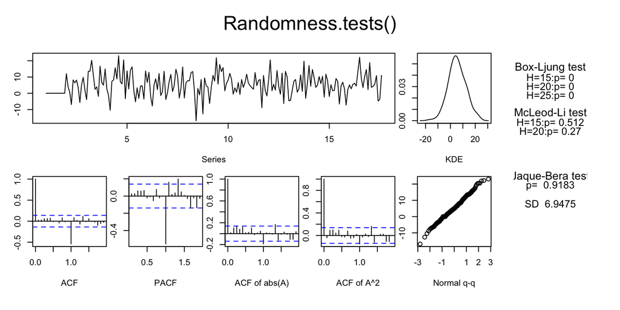

```
##   B-L test H0: the series is uncorrelated
##   M-L test H0: the square of the series is uncorrelated
##   J-B test H0: the series came from Normal distribution
##   SD         : Standard Deviation of the series
```

```
##      BL15 BL20 BL25  ML15 ML20    JB    SD
## [1,]    0    0    0 0.512 0.27 0.918 6.947
```

```r
  Randomness.tests(Fit3$resid)
```

## c) Random Trend

- Suppose $s=12$, and your observation $Y_t$ has random walk without drift as trend, together with the seasonality.
  $$Y_t = W_t + S_t + X_t.$$
  Where
  $$W_t \hspace{3mm} = \hspace{3mm} \sum_{i=1}^t e_i \hspace{10mm} e_i \sim_{iid} N(0,\sigma^2).$$
- If you take seasonal difference,
  $$\begin{align*}
  \bigtriangledown_{12} Y_{t}
  &= \hspace{3mm} W_t \hspace{5mm} + S_t \hspace{5mm} + X_t \\ \\
  &- \hspace{3mm} W_{t-12} - S_{t-12} - X_{t-12} \\ \\
  &= \hspace{3mm} (W_t - W_{t-12}) + (X_t - X_{t-12}) \\
  \end{align*}$$
- The first part,
  $$W_{t} - W_{t-12}
  \hspace{3mm} = \hspace{3mm} \sum_{i=0}^{t-1} e_{t-i} - \sum_{i=12}^{t-1} e_{t-i} \\
  \hspace{3mm} = \hspace{3mm} \sum_{i=0}^{11} e_{t-i} \hspace{10mm} \sim N(0,12\sigma^2)$$
- This is MA(11) with unit root. (non-invertible)

## __Ex. Random Trend w/o Drift

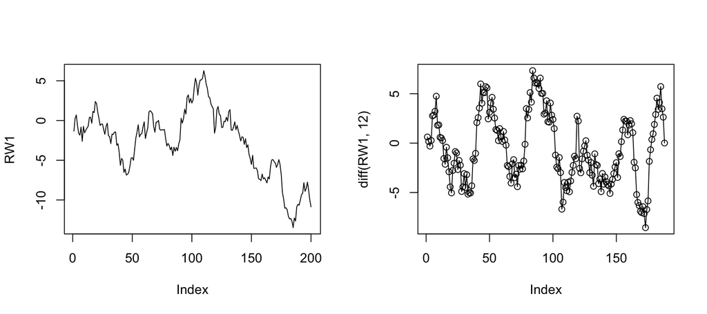

```r
  library(forecast)
  source('https://nmimoto.github.io/R/TS-00.txt')


  #--- RW without drift ---
  set.seed(5351)
  RW1 <- cumsum(rnorm(200, 0, 1))
  layout(matrix(1:2, 1,2))
  plot(RW1, type="l")
  plot(diff(RW1, 12), type="o")
```

```r
  RW2 <- ts(RW1, start=c(1,1), freq=12)
  auto.arima(RW2, D=1)
```

```
## Series: RW2
## ARIMA(1,0,0)(1,1,0)[12] with drift
##
## Coefficients:
##          ar1     sar1    drift
##       0.9458  -0.5853  -0.0473
## s.e.  0.0224   0.0590   0.0751
##
## sigma^2 estimated as 1.301:  log likelihood=-293.38
## AIC=594.75   AICc=594.97   BIC=607.7
```

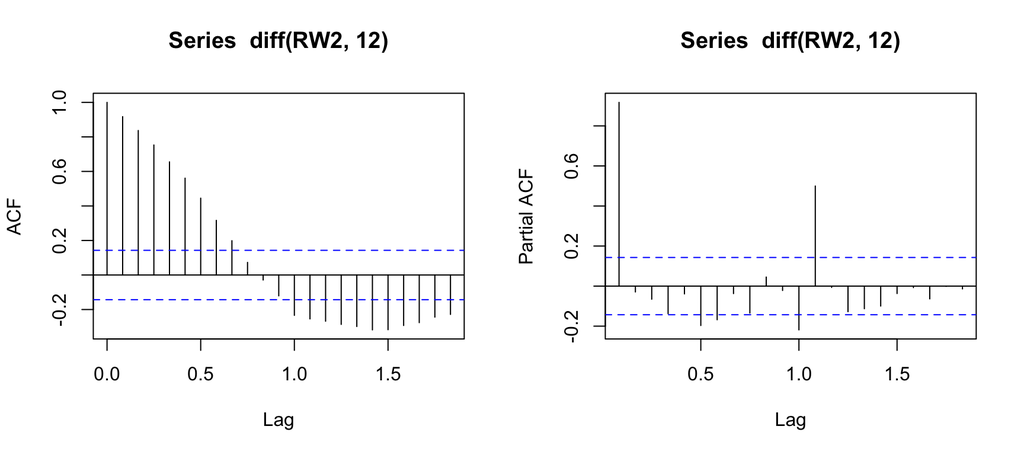

```r
  acf(diff(RW2, 12))
  pacf(diff(RW2, 12))
```

```r
  Arima(RW2, order=c(0,0,12), seasonal=c(0,1,0))
```

```
## Series: RW2
## ARIMA(0,0,12)(0,1,0)[12]
##
## Coefficients:
##          ma1     ma2     ma3     ma4     ma5     ma6     ma7     ma8     ma9
##       0.9835  0.9878  1.0476  1.0295  1.0445  1.0440  1.0296  1.0460  0.9855
## s.e.  0.0877  0.0926  0.1073  0.1188  0.1250  0.1207  0.1203  0.1103  0.1063
##         ma10    ma11     ma12
##       0.9827  0.9643  -0.0351
## s.e.  0.0963  0.1055   0.0823
##
## sigma^2 estimated as 0.9189:  log likelihood=-269.31
## AIC=564.62   AICc=566.71   BIC=606.69
```